# Week 03: Data viz exploration

Author

STAT 7500

Published

September 21, 2026

## R Tips of the Day

1. Take notes in this document! Will serve as a useful reference for homework
2. The “Save” Icon (+ Rendering)
3. Code chunks
   - code goes on new line, NOT in curly brackets
   - Make sure “Play” button is visible
   - Source vs. Visual viewer
   - Suppressing messages, warnings, etc
   - echo
   - eval
4. Installing packages
5. Console versus .qmd

## Goals

Today, we will practice using visualization as a tool for **asking and refining questions**, not just answering questions we already have.

By the end of class, you should be able to:

- translate a question into a visualization;
- build and revise a `ggplot` in layers;
- describe what a visualization reveals and what it makes you wonder;
- make purposeful choices about plot type, aesthetics, and faceting.

You do not need to submit this practice. Follow along, experiment, and keep notes that will be useful for the homework.

## Packages

```r
library(tidyverse)
library(viridis)
library(ggbeeswarm)
```

## Meet the data

The `midwest` data frame is included in the **ggplot2** package. It contains demographic characteristics of counties in five Midwestern states.

Run `?midwest` in the Console to open the documentation.

### Before we plot

With a partner, take two minutes to inspect the variable names and documentation.

1. What does each row represent?
2. Which variables catch your attention?
3. Write down **at least two questions** that these data might help us explore. Do not worry yet about how to code them.

## Cycle 1: Start simple, then notice

### One numerical variable

We will start with a broad question:

> How does population density vary across Midwestern counties?

```
Orientation inferred to be along y-axis; override with
`position_beeswarm(orientation = 'x')`
```

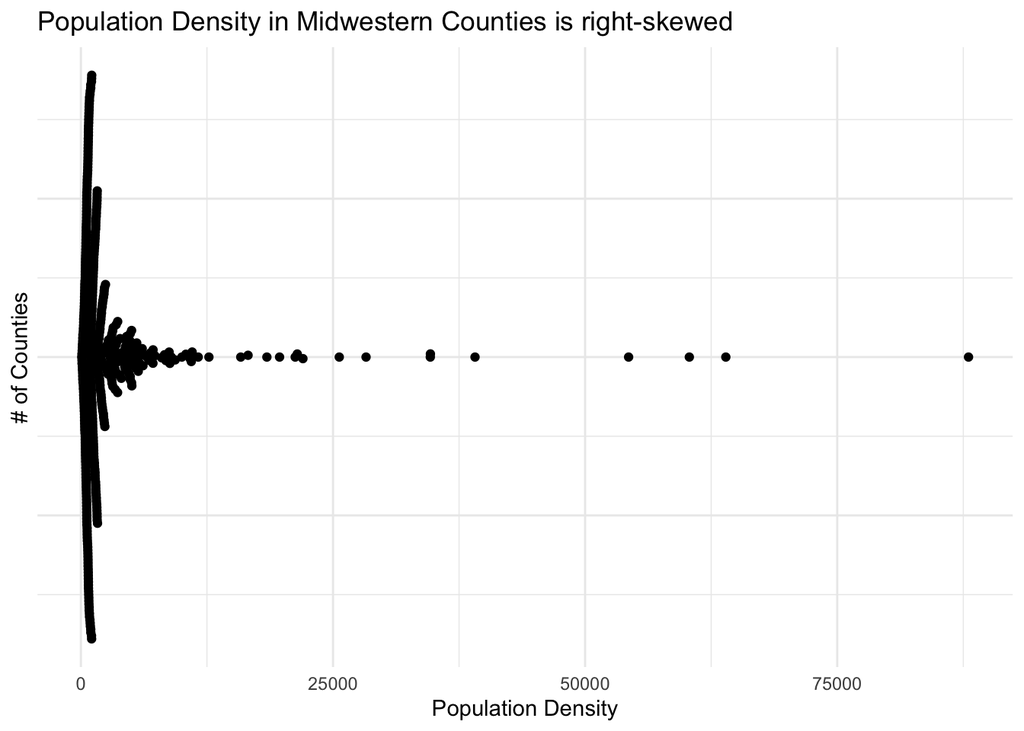

```r
# Live code here
# make sure to add informative titel and x-axis label

ggplot(midwest, aes(x = popdensity, y = 1))+
  geom_beeswarm()+
  theme_minimal()+
  labs(x = "Population Density", y = "# of Counties",
       title = "Population Density in Midwestern Counties is right-skewed")+
  theme(axis.ticks.y = element_blank(), axis.text.y = element_blank())
```

### Pause: notice and wonder

### Your turn

Explore the distribution of county poverty rates (`percbelowpoverty`).

1. Create an appropriate visualization.
2. Try at least two values for `bins` or `binwidth`. Which version helps you see the distribution more clearly?
3. Give the plot an informative title and x-axis label.
4. Be ready to share one thing you notice or wonder.

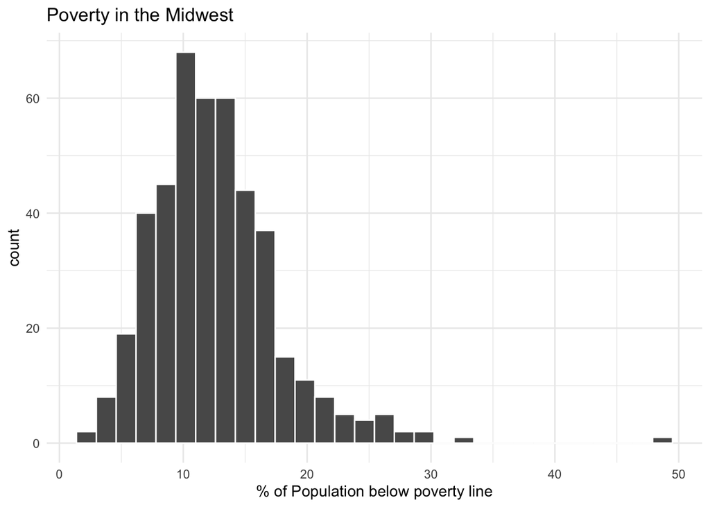

```r
ggplot(midwest, aes(x = percbelowpoverty))+
  geom_histogram(color = "white")+
  theme_minimal()+
  labs(x = "% of Population below poverty line", title = "Poverty in the Midwest")
```

```r
# Your code here
```

- Faceting is a keyway

## Cycle 2: Use categories to compare groups

### Watch: one numerical and one categorical variable

> Do counties in some states tend to be geographically larger than counties in others?

Before we code:

- What type of variable is `area`?
- What type of variable is `state`?
- Which visualization would help us compare the distribution of `area` across states?

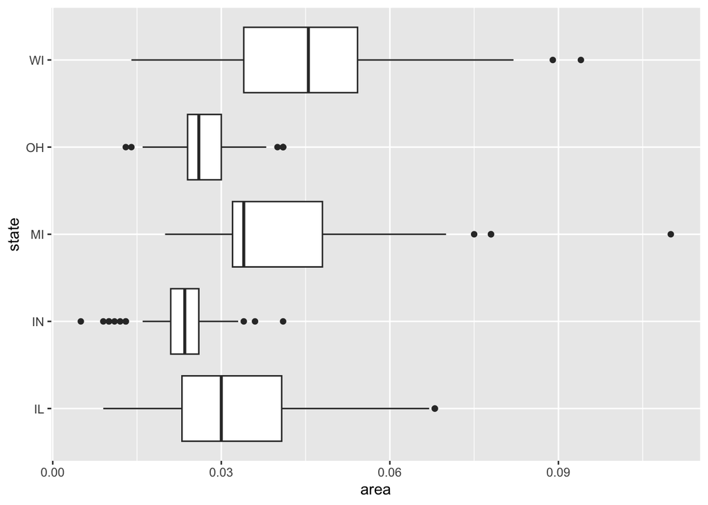

```r
# Live code here

ggplot(midwest, aes(y = state, x = area))+
  geom_boxplot()
```

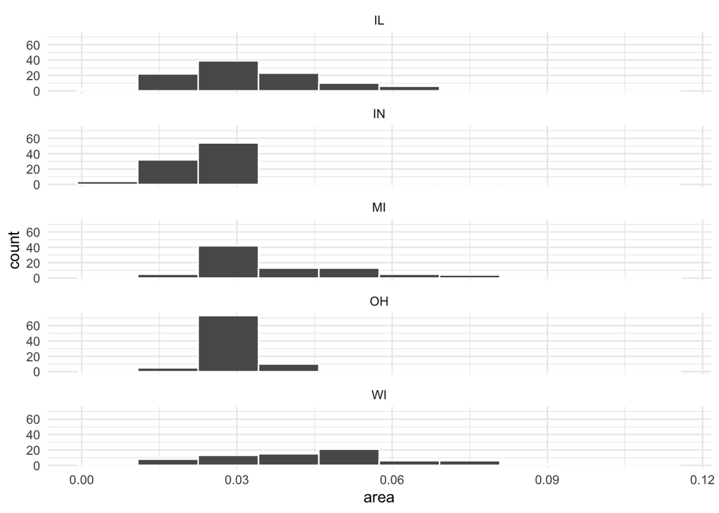

```r
ggplot(midwest, aes(x = area))+
  geom_histogram(color = "white", bins = 10)+
  facet_wrap(~state,ncol = 1) +
  theme_minimal()
```

### Pause: interpret the comparison

Discuss with your partner:

- What differences among states are visible?
- What features of the distributions would we miss if we compared only the mean area in each state?

### From one categorical variable to two

The variable `inmetro` indicates whether a county is located in a metropolitan area. Run the code below to create a clearer categorical version of this variable.

```r
midwest <- midwest |>
  mutate(metro = if_else(inmetro == 1, "Metro", "Non-metro"))
```

### Predict before plotting

Consider these two questions:

1. Which states have the **largest numbers** of metro and non-metro counties?
2. In which states is the **largest proportion** of counties metropolitan?

Would the same plot answer both questions? What would need to change?

### Watch: compare counts

We will first create a plot that answers the question about the **number** of counties.

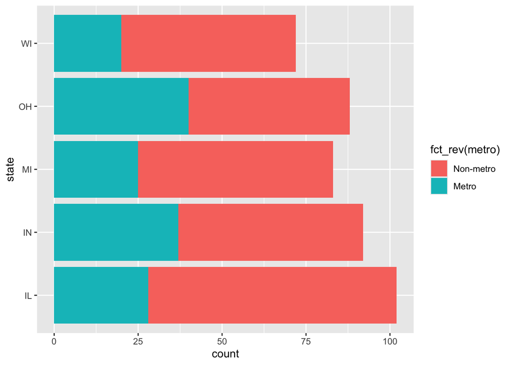

```r
ggplot(midwest) +
  geom_bar(aes(y = state, fill = fct_rev(metro)))
```

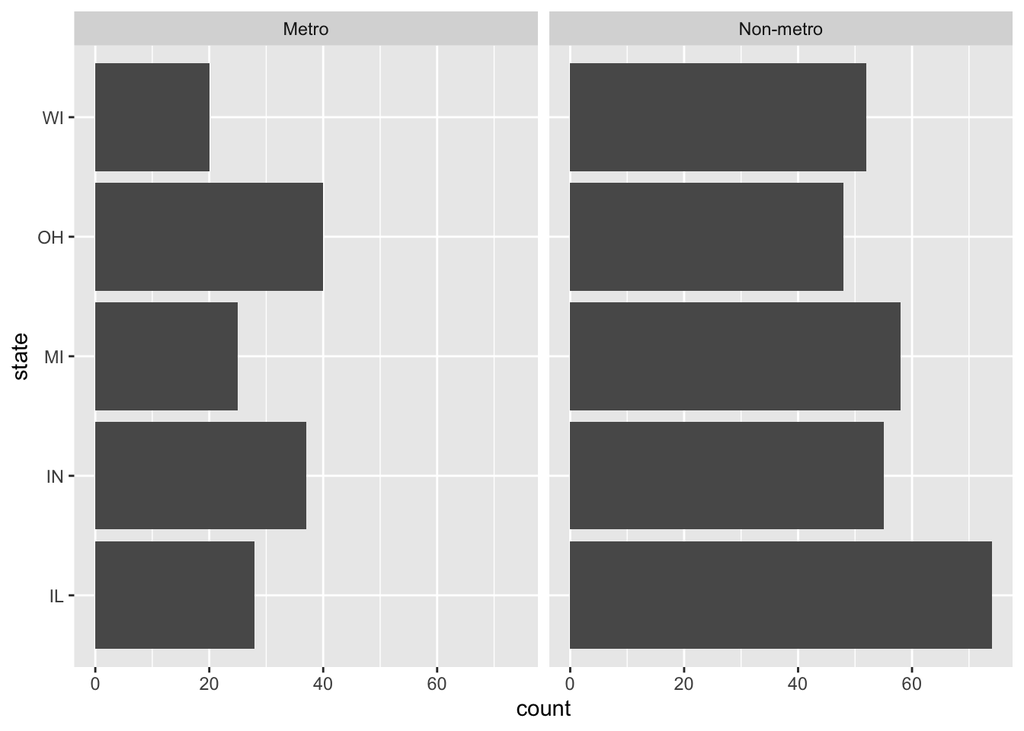

```r
ggplot(midwest) +
  geom_bar(aes(y= state))+
  facet_wrap(~metro)
```

### Your turn: compare proportions

Modify the plot so that each bar has the same total height and displays proportions rather than counts. Add informative axis labels, a legend title, and a plot title.

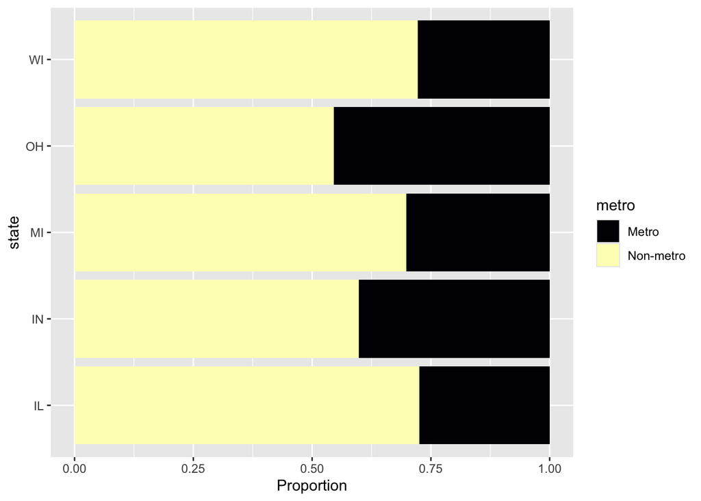

```r
ggplot(midwest, aes(y = state, fill = metro)) +
  geom_bar(position = "fill") +
  labs(x = "Proportion") +
  scale_fill_viridis_d(option = "A")
```

```r
# Your code here
```

Discuss with your partner:

- Which question does each plot answer?
- What becomes easier to compare in the proportion plot?
- What incorrect conclusion might someone draw if they used the count plot to compare proportions?

## Cycle 3: Build a relationship, then complicate it

### Two numerical variables

> What is the relationship between the percentage of adults with a college degree (`percollege`) and the percentage of people below the poverty line (`percbelowpoverty`)?

Before we code: What plot type fits this question? What would you expect to see?

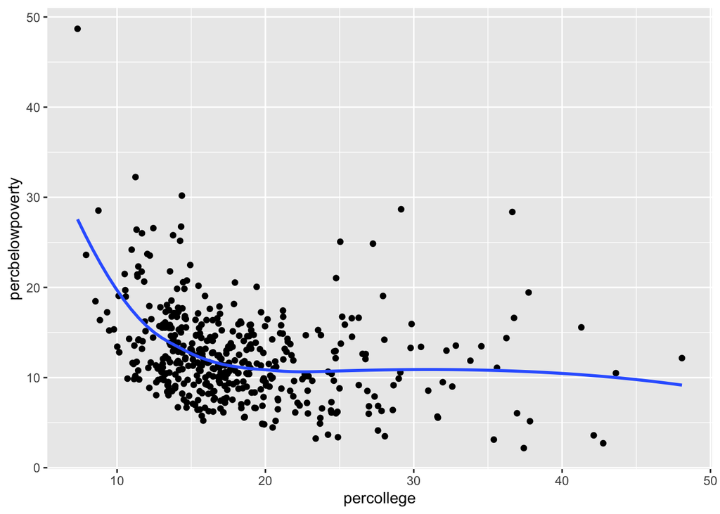

```r
# Live code here
ggplot(midwest, aes(x = percollege, y = percbelowpoverty)) +
  geom_point() +
  geom_smooth(se = FALSE)
```

```r
## the grey area is margin of error
```

### What should we try next?

The first plot is rarely the final plot. What could explain variation or help us see the relationship more clearly?

We will choose one idea from the class and revise the plot.

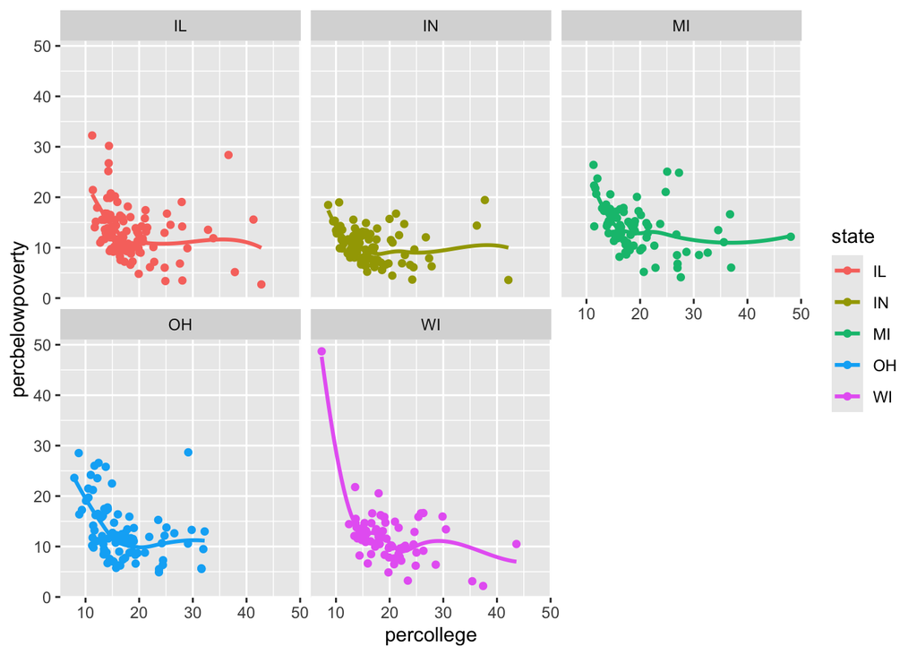

```r
# Revise the plot here
ggplot(midwest, aes(x = percollege, y = percbelowpoverty, color = state)) +
  facet_wrap(~state) +
  geom_point() +
  geom_smooth(se = FALSE)
```

### Your turn

Create a version of the college–poverty plot with a separate panel for each state.

- Add a smooth curve to each panel with `geom_smooth(se = FALSE)`.
- Include clear labels.
- Compare this plot with the original: What becomes easier to see? What becomes harder to see?

```r
# Your code here
```

> **Interpretation:**

## Open exploration: follow a question

Return to the questions you generated at the beginning or write a new question inspired by today’s plots. With your partner:

1. State one question you want to investigate.
- Does Population density correlate with poverty.
2. Identify the variable or variables involved and their types.
- population density, percentage below poverty line
3. Choose a plot that fits the question.
- scatter-plot
4. Create a first version.
5. Look at it and revise **one thing** in response to what you see.
6. Record one finding and one follow-up question.

You may use the [ggplot2 reference](https://ggplot2.tidyverse.org/reference/) or code from the lecture slides.

> **Question:**

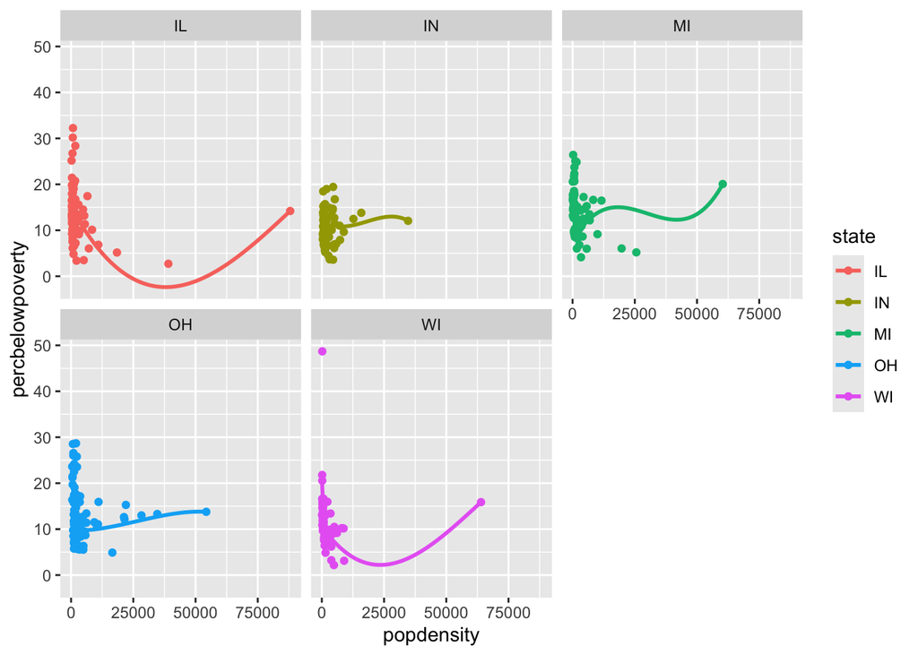

```r
ggplot(midwest, aes(x = popdensity, y = percbelowpoverty, color = state)) +
  facet_wrap(~state) +
  geom_point() +
  geom_smooth(se = FALSE)
```

```r
# Your code here
```

> **What we found:**

> **What we wonder next:**